Note

Go to the end to download the full example code. or to run this example in your browser via JupyterLite or Binder

# Plot the decision boundaries of a VotingClassifier

Plot the decision boundaries of a `VotingClassifier` for two features of the Iris dataset.

First, three exemplary classifiers are initialized (`DecisionTreeClassifier`, `KNeighborsClassifier`, and `SVC`) and used to initialize a soft-voting `VotingClassifier` with weights

```
[2,
1, 2]
```

, which means that the predicted probabilities of the `DecisionTreeClassifier` and `SVC` each count 2 times as much as the weights of the `KNeighborsClassifier` classifier when the averaged probability is calculated.

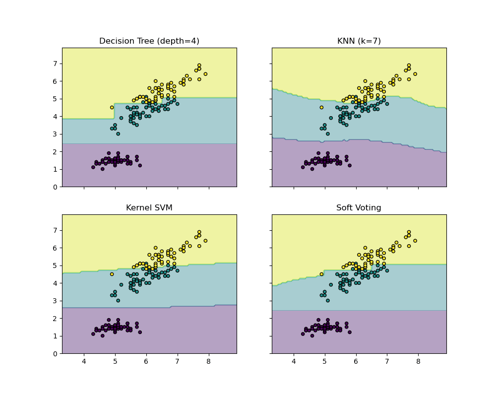

```
# Authors: The scikit-learn developers
# SPDX-License-Identifier: BSD-3-Clause

from itertools import product

import matplotlib.pyplot as plt

from sklearn import datasets
from sklearn.ensemble import VotingClassifier
from sklearn.inspection import DecisionBoundaryDisplay
from sklearn.neighbors import KNeighborsClassifier
from sklearn.svm import SVC
from sklearn.tree import DecisionTreeClassifier

# Loading some example data
iris = datasets.load_iris()
X = iris.data[:, [0, 2]]
y = iris.target

# Training classifiers
clf1 = DecisionTreeClassifier(max_depth=4)
clf2 = KNeighborsClassifier(n_neighbors=7)
clf3 = SVC(gamma=0.1, kernel="rbf", probability=True)
eclf = VotingClassifier(
    estimators=[("dt", clf1), ("knn", clf2), ("svc", clf3)],
    voting="soft",
    weights=[2, 1, 2],
)

clf1.fit(X, y)
clf2.fit(X, y)
clf3.fit(X, y)
eclf.fit(X, y)

# Plotting decision regions
f, axarr = plt.subplots(2, 2, sharex="col", sharey="row", figsize=(10, 8))
for idx, clf, tt in zip(
    product([0, 1], [0, 1]),
    [clf1, clf2, clf3, eclf],
    ["Decision Tree (depth=4)", "KNN (k=7)", "Kernel SVM", "Soft Voting"],
):
    DecisionBoundaryDisplay.from_estimator(
        clf, X, alpha=0.4, ax=axarr[idx[0], idx[1]], response_method="predict"
    )
    axarr[idx[0], idx[1]].scatter(X[:, 0], X[:, 1], c=y, s=20, edgecolor="k")
    axarr[idx[0], idx[1]].set_title(tt)

plt.show()
```

**Total running time of the script:** (0 minutes 0.654 seconds)

[figure not shown]

[`Download Jupyter notebook: plot_voting_decision_regions.ipynb`](https://scikit-learn.org/1.6/_downloads/905bd7d135e7fe5fdec55e4f0aa77420/plot_voting_decision_regions.ipynb)

[`Download Python source code: plot_voting_decision_regions.py`](https://scikit-learn.org/1.6/_downloads/12b6dbb270865986bd1c9bbf7ce24cb0/plot_voting_decision_regions.py)

[`Download zipped: plot_voting_decision_regions.zip`](https://scikit-learn.org/1.6/_downloads/04b9a7769df5b331f4d94e1d065b4311/plot_voting_decision_regions.zip)

#### Related examples

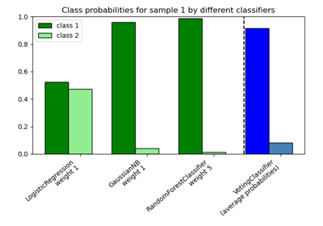

Plot class probabilities calculated by the VotingClassifier

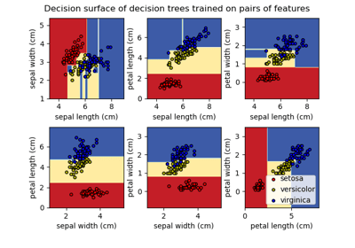

Plot the decision surface of decision trees trained on the iris dataset

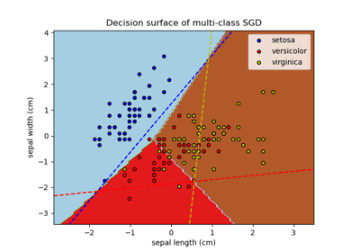

Plot multi-class SGD on the iris dataset

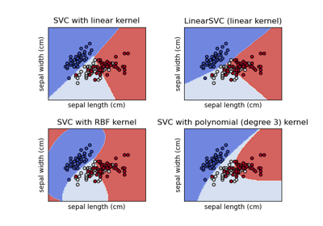

Plot different SVM classifiers in the iris dataset

© 2007–2025 The scikit-learn developers  
Licensed under the 3-clause BSD License.  
https://scikit-learn.org/1.6/auto_examples/ensemble/plot_voting_decision_regions.html